# Mitocall Pipeline

Jip van Dinter

2020-06-19

## Introduction

This vignette serves as a tutorial for a pipeline to call mutations in mitochondrial DNA adapted from the [GATK pipeline](https://github.com/gatk-workflows/gatk4-mitochondria-pipeline) and filter for somatic mutations. It will guide you how to process your **WGS hg38 BAM file** into an **R dataframe** containing potential somatic mutations. In addition it will show some basic plotting functions to visualise the data and some models we have created for our own dataset.

**Required input**:

- hg38 WGS BAM file
- File with median / mean coverage of the autosome from the IAP pipeline
  - Located for our IAP in: `HG38_MAP_LOC/QCSTATS/SAMPLE_dedup/SAMPLE_dedup.WGSMetrics.txt`
  - The python script assumes this file structure as input. If this is not the case, it is better to create a small script yourself to finish the JSON files.
- Reference fasta
- List / table of samples and additional data
  - An example can be found under `Downstream Analysis`

**Required software**:

- **For the WDL pipeline**:
  - Cromwell v29 or later
  - GATK 4.1.2 or later
  - SGE backend (SLURM backend support might be released)
- **For the analysis**:
  - R version 4.0.0 or later
  - The analysis in R requires the following packages:

```r
tidyverse
ggbeeswarm
MutationalPatterns
VariantAnnotation
ggpubr
ggrepel
ggsci
RColorBrewer
lme4
nlme
regioneR
karyoploteR
magrittr
car
BSgenome.Hsapiens.UCSC.hg38
gridExtra
```

## Installing Cromwell

Cromwell is required for the WDL files to run. There are multiple ways to install Cromwell for your local machine or on your local cluster:

- For your local machine:
  - https://cromwell.readthedocs.io/en/stable/Getting/
- For your local cluster:
  - https://cromwell.readthedocs.io/en/stable/backends/HPC/
  - Ask your system admins for help!

## Setting up the pipeline folder structure

Before we can run the pipeline, we first need to set up our base of operations; the workflow directory. Download all the files required from my [GitHub page](https://github.com/jvandinter/MitoCallPipeline) and put them in your chosen directory like this:

**MAIN directory**

- `application.conf.mito.31`
- `mitopipeline.config`
- `mitolib-0.1.2.jar`
- `mito_pipeline_start.sh`
- `mito_pipeline_run.sh`
- `final_mito_output.sh`
- `WDL folder`
- `INPUT folder`

**WDL directory**

- `AlignAndCall.wdl`
- `MitochondriaPipeline.wdl`
- `AlignmentPipeline.wdl`

**Inputs directory**

- `finish_mitocall_jsons.py`
- `mitochondrial_workflow_inputs_unfinished.json`
- (The `options.json` will be generated per sample)

**Resources directory**

- `MT pipeline resource files from the` [GATK bucket](https://github.com/jvandinter/MitoCallPipeline/tree/master/MAIN/Resources) `I have hosted`
- `This does not have to be in the` *MAIN directory*`, it can go anywhere else as long as you update mitochondrial_workflow_inputs_unfinished.json`

> **!!!** If this is a first-time setup, open `mitochondrial_workflow_inputs_unfinished.json` in your favorite text editor and change the location of all files to the correct location where you stored the resource files.

Open the `mitopipeline.config` file and edit the path of the following variables:

- `MAIN_DIR`
  - This is the main directory which contains all the required files for the analysis
- `WORK_LOC`
  - This is the directory name which will contain all the output folders
- `INPUT_LOC`
  - The inputs and options JSON directory. Also should include the python script and the unfished input JSON.
- `WDL_LOC`
  - The directory name where all the pipeline WDLs are stored
- `CROMWELL_LOC`
  - The location of the cromwell jar file on the HPC.
- `HG38_MAP_LOC`
  - This is the folder which contains the hg38 IAP output and where the scripts searches for the WGSMetrics.txt file. If it is not present, please re-generate the summary statistics files for optimal variant calling, otherwise the coverage will be set to a default 30.
- `EMAIL`
  - This is the email that will be used in the annotate_vcf steps

### Run the script

You can now run the pipeline with the following command in your environment:

```r
cd `Insert your MAIN_dir here`
```

```r
qsub mito_pipeline_start.sh `your email`
```

Each sample will take on average 30 minutes

> **!!!** If the files fail due to reaching the time limit, just submit the job again. The script will automatically detect which samples have been finished and continue on with the others.

When they are all finished, you have to retrieve the output from all subfolders by running the following command:

```r
qsub final_mito_output.sh
```

The script will automatically get the output directory from the `mitopipeline.config`.

### Optional: annotate VCF files using the vanBoxtel IAP

First, run the following command:

```r
qsub convert_chrM_to_MT.sh`
```

This script will do two things:

1. Change chrM to MT in all VCFs
2. Annotate the variants located in the VCFs

All the annotated VCF files are located in `MAIN_LOC/annotated_vcfs/`.

## Downstream analysis

Firstly, copy the output and annotated_vcfs files from your local cluster to your local computer or source them from the cluster.

**Required files:**

- All (annotated) VCF files
- SAMPLE_WGSMetrics.txt file per sample (if interested in copy number variation)
- All function files found on [GitHub](https://github.com/jvandinter/MitoCallPipeline/tree/master/functions)
- The following packages:

> **!!!** Some packages require **BioCManager** for their correct installation. Use the following command:

```
BiocManager::install('package')
```

```r
library(tidyverse)
library(ggbeeswarm)
library(MutationalPatterns)
library(VariantAnnotation)
library(ggpubr)
library(ggrepel)
library(lme4)
library(nlme)
library(regioneR)
library(karyoploteR)
library(magrittr)
library(car)
library(BSgenome.Hsapiens.UCSC.hg38)
library(gridExtra)
```

When building your own sample reference data frame, follow the structure of the following DF, otherwise the functions in this vignette will not work:

```
#>        sample patient   age   state  bulk
#> 1    AC41HSC3    AC41 41.75 healthy clone
#> 2    AC41MPP3    AC41 41.75 healthy clone
#> 3 AC41MSCBULK    AC41 41.75 healthy  bulk
#> 4   AC63HSCc2    AC63 63.75 healthy clone
#> 5   AC63MPPc1    AC63 63.75 healthy clone
#> 6 AC63MSCBULK    AC63 63.75 healthy  bulk
```

Initiate the following parameters in R:

```r
plotdir <- 'E:/mito_internship/plots'
vcf_wd <- 'E:/mito_internship/_annotated_vcfs'
wgs_wd <- 'E:/mito_internship/output'
function_wd <- 'E:/mito_internship/scripts/Restructured/Downstream_post_processing/functions'
vcf_filter <- "*\\_snpSift.vcf$" # To select annotated VCFs
ref_genome <- "BSgenome.Hsapiens.UCSC.hg38"
low_vaf_filter <- 0.01 # The lower and upper bound of VAF filtering, as by GATK recommendation
high_vaf_filter <- 0.99
```

When all parameters are set up, you can execute the following commands to load all functions from your function directory:

```r
setwd(function_wd)
files_list <- list.files(pattern = '.R$', ignore.case = T)
sapply(files_list, source, .GlobalEnv)
```

Let’s first take a look at the coverage of the samples, to see whether they reach the threshold of at least 1000 coverage:

```r
cnv_df <- calculate_mito_cnv(wd = wgs_wd,
                             mito_reference_df = sample_reference_df)
```

To plot the coverage, you can use the following code:

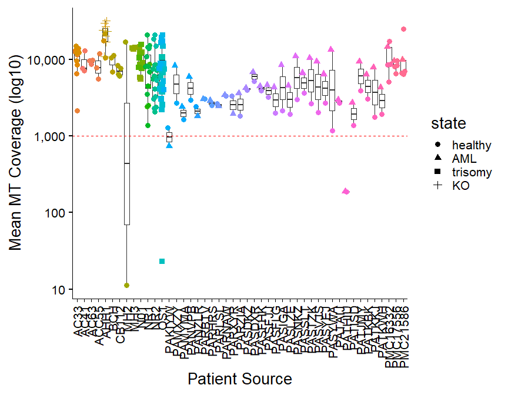

```r
plot_coverage = ggplot(cnv_df,
                       aes(x = patient,
                           y = mt_mean)) +
  geom_boxplot(outlier.shape = NA) +
  geom_quasirandom(aes(col = sample, shape = state),
                   size = 3) +
  geom_hline(yintercept = 1000,
             col = 'red',
             linetype = 2) +
  xlab("Patient Source") +
  ylab("Mean MT Coverage (log10)") +
  theme_BM() +
  theme(axis.text.x = element_text(angle = 90,
                                   vjust = 0.5,
                                   hjust = 1)) +
  guides(color=FALSE) +
  scale_y_log10(labels = scales::comma)

plot_coverage
```

The following code snippet can help you to save the plots generated:

```r
plotname <- paste(plotdir,'optional_folder_name','name_of_plot', sep ='/')

# Put your plot code here and save it as a variable
plot = ggplot(data, aes( x = x, y = y)) +
  geom_point()

ggsave(paste(plotname,
             'pdf',
             sep = '.'),
       width = 11.69,
       height = 8.27,
       plot,
       device = 'pdf')
```

In my experience, samples that had less than 1000 coverage either outputted almost no somatic variants at all, or had many false positives. Best to remove the samples that did not meet the coverage threshold from your sample reference data frame with the following command:

```r
removed_samples <- cnv_df[,cnv_df$cnv_mean < 1000]$sample
sample_reference_df <- filter(sample_reference_df, !(sample %in% removed_samples))
```

With the final sample list, we can start loading the VCFs.

### Loading the data

Use the following functions to load the VCF variants into R:

```r
passed_vcflist <- filter_passed_variants(ref_genome = ref_genome,
                                   wd = vcf_wd,
                                   vcf_filter = vcf_filter)

all_variants <- grab_all_variants(ref_genome = ref_genome,
                             wd = vcf_wd,
                             vcf_filter = vcf_filter,
                             mito_reference_df = sample_reference_df)

annotated_variants <- grab_variant_annotations(vcf_filter = vcf_filter)
```

These functions will use the files for various things:

- **Per_base_coverage**
  - Output is a data frame containing a base-per-base coverage overview for each sample
- **Get_vaf_df**
  - Output is a data frame which holds the Variant Allele Frequency per variant
- **create_variant_df**
  - Take all PASSED variants from passed_vcflist and puts them in a data frame. Annotates variants with sample of origin, patient origin, etc.
- **filtered_variants**
  - Filter variants on quality variables (see [the final report](https://github.com/jvandinter/MitoCallPipeline/tree/master/Report))
- **somatic_variant_df**
  - Filter variants on VAF

```r
# For QC coverage plots
per_base_coverage <- calculate_mt_coverage(wd = wgs_wd,
                                  mito_reference_df = sample_reference_df)
# Calculate VAF of each variant
vaf_df <- get_vaf_df(vcf_list = passed_vcflist)

# Load passed variants in DF
variant_df <- create_variant_df(vcf_list = passed_vcflist,
                                mito_reference_df = sample_reference_df)

# Filter variants (see final report)
filtered_variants <- filter_variants(variant_df = variant_df,
                              vcf_all_df = all_variants,
                              sample_reference_df = sample_reference_df)

# Filter variants on VAF
somatic_variant_df <- combine_mito_data(shared_mutation_output = filtered_variants,
                         vaf_output = vaf_df,
                         low_vaf_filter = low_vaf_filter,
                         high_vaf_filter = high_vaf_filter)
```

This will create a coverage plot for each sample:

```r
sapply(sample_reference_df$sample, function(x) {
  plot_cov(per_base_coverage,
           x,
           paste(plotdir,'Coverage',sep = '/'))
})
```

Like so:

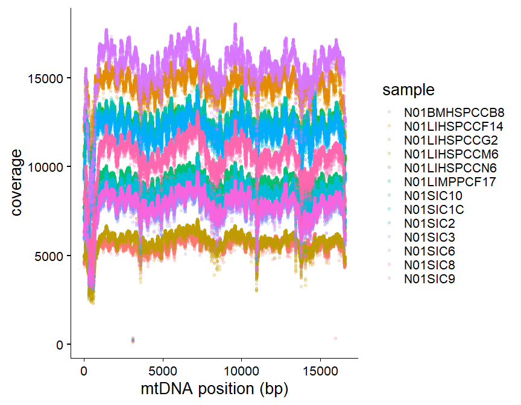

```r
plot_cov(per_base_coverage, 'N01', paste(plotdir,'Coverage',sep = '/'))
```

Here, we split the INDELs from the SNVs and annotate the variants where applicable.

- *count_variant_occurences*
  - Calculates the number of somatic mutations per sample

```r
# Calculate number of mutations per sample

total_sample_mutation_freq <- count_variant_occurences(combined_mito_df = somatic_variant_df,
                                                       mito_reference_df =sample_reference_df)

# Split SNPs and INDELs

indel_df <- filter(somatic_variant_df,
                   nchar(somatic_variant_df$ref) > 1 | nchar(somatic_variant_df$alt) > 1)
indel_df$indel <- ifelse(nchar(indel_df$ref) > nchar(indel_df$alt),
                         'deletion',
                         'insertion')
indel_annotate <- left_join(indel_df, annotated_variants,
                               by = c('variant', 'sample'))

# Remove INDELs from somatic_variant_df

somatic_variant_df <- anti_join(somatic_variant_df, indel_df,
                 by = 'variant')
somatic_variant_annotate <- left_join(somatic_variant_df, annotated_variants,
                          by = c('variant', 'sample'))

# Calculate number of mutations per sample

total_sample_mutation_freq <- count_variant_occurences(combined_mito_df = somatic_variant_df,
                                                       mito_reference_df =sample_reference_df)
```

To plot an overview of the number of mutations per group, you can use:

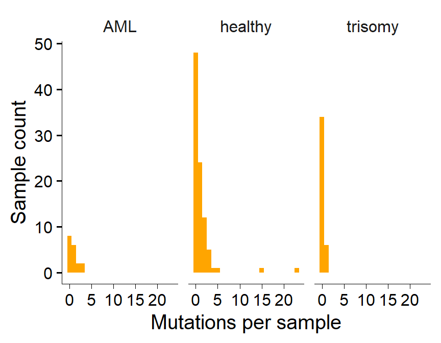

```r
plot <- ggplot(subset(total_sample_mutation_freq,
                      state %in% c('healthy','trisomy','AML'))) +
  geom_histogram(aes(x = freq),
                 fill = 'orange',
                 binwidth = 1) +
  theme_BM(base_size = 30) +
  xlab('Mutations per sample') +
  ylab('Sample count') +
  facet_wrap(. ~ state)

plot
```

To make work with the data easier, I create new dataframes for specific analyses. To keep this vignette succinct, I will only give 1 single example per analysis.

```r
# Subset DFs to only healthy variants
healthy_variants <- subset(somatic_variant_annotate,
                           state == 'healthy' &
                           !(patient == 'AHH1') &
                           bulk == 'clone')
healthy_cnv <- subset(cnv_df,
                      state == 'healthy' &
                      !(patient == 'AHH1') &
                      mt_mean > 1000 &
                      bulk == 'clone')
healthy_freq <- subset(total_sample_mutation_freq,
                       state == 'healthy' &
                       !(patient == 'AHH1') &
                       bulk == 'clone')

# Subset DFs to only foetal variants
foetus_cnv <- subset(cnv_df,
                     state %in% c('healthy','trisomy') &
                     patient %in% c('N01','OS1','MH2','MH3','NR1','NR2') &
                     !(sample %in% foetus_remove) &
                     mt_mean > 1000 &
                     bulk == 'clone')
foetus_freq <- subset(total_sample_mutation_freq,
                      state %in% c('healthy','trisomy') &
                      patient %in% c('N01','OS1','MH2','MH3','NR1','NR2') &
                      bulk == 'clone')
```

## The Analyses

### Mutational spectra

To plot the mutation spectra with *MutationalPatterns* and *KaryoplotR*, the variants have to be in a Granges object. A subset of the data is made to look for possible strand bias. The Granges objects will be generated with the following code:

```r
healthy_c_t <- subset(healthy_variants, ref %in% c('C','T'))

healthy_g_a <- subset(healthy_variants, ref %in% c('G','A'))

healthy_granges <- unique(GRanges(seqnames = Rle("chrM", nrow(healthy_variants)),
                    ranges = healthy_variants$mut_pos,
                    strand = rep('*', nrow(healthy_variants)),
                    ref = healthy_variants$ref,
                    alt = healthy_variants$alt))

healthy_ct_granges <- unique(GRanges(seqnames = Rle("chrM", nrow(healthy_c_t)),
                      ranges = healthy_c_t$mut_pos,
                      strand = rep('*', nrow(healthy_c_t)),
                      ref = healthy_c_t$ref,
                      alt = healthy_c_t$alt))

healthy_ga_granges <- unique(GRanges(seqnames = Rle("chrM", nrow(healthy_g_a)),
                      ranges = healthy_g_a$mut_pos,
                      strand = rep('*', nrow(healthy_g_a)),
                      ref = healthy_g_a$ref,
                      alt = healthy_g_a$alt))
```

*single_type_occurences* will output a count dataframe with count data for each type of mutation.

```r
healthy_mutprof <- single_type_occurence(healthy_granges,
                                          ref_genome,
                                          healthy_freq)
healthy_ct_mutprof <- single_type_occurence(healthy_ct_granges,
                                    ref_genome,
                                    healthy_freq)
healthy_ga_mutprof <- single_type_occurence(healthy_ga_granges,
                                    ref_genome,
                                    healthy_freq)

healthy_combined <- rbind(healthy_mutprof, healthy_ct_mutprof, healthy_ga_mutprof)
```

Finally, plot the mutational spectra with the following code:

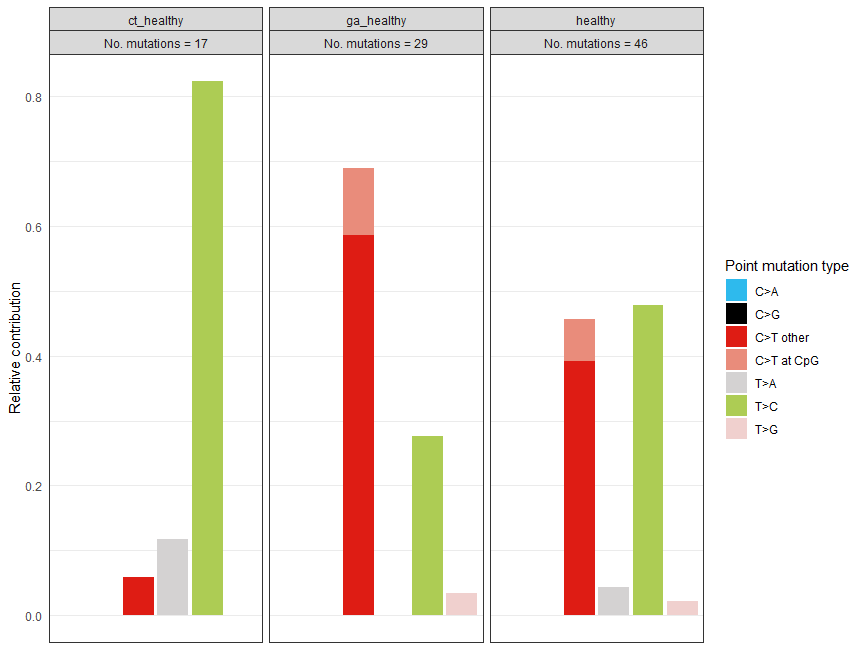

```r
plot <- plot_spectrum(healthy_combined, CT = TRUE, by = c('healthy','ct_healthy','ga_healthy'))
plot
```

### Rainfall plot

Rainfall plots show the genomic distribution of mutations and visualises clusters of mutations close together. By replacing **healthy_grangres** with **healthy_ct_granges** or your equivalent, you can see whether the distribution is different for G/A or C/T reference nucleotides.

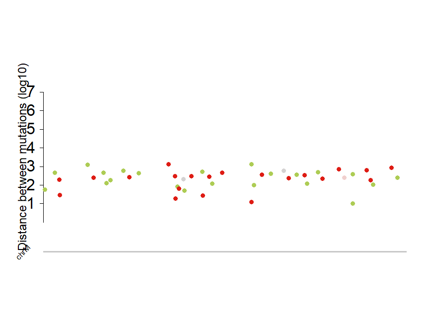

```r
COLORS6 = c('C>A' = "#2EBAED", 'C>G' = "#000000", 'C>T' = "#DE1C14",'T>A' = '#D4D2D2',
           'T>C' = "#ADCC54", 'T>G' = "#F0D0CE")

healthy.colors <- getVariantsColors(healthy_granges$ref, healthy_granges$alt, color.table = COLORS6)

kp <- plotKaryotype(chromosomes = 'chrM',
                    genome = 'hg38',
                    ideogram.plotter = NULL,
                    labels.plotter = NULL)
kpAddCytobandsAsLine(kp)
kpAddChromosomeNames(kp,
                     srt=45)
kpAxis(kp, ymax = 7,
       tick.pos = 1:7,
       cex = 2)
kpPlotRainfall(kp,
               data = healthy_granges,
               col = healthy.colors,
               cex = 1.2)
kpAddLabels(kp, labels = c("Distance between mutations (log10)"),
            srt=90,
            pos=1,
            label.margin = 0.06,
            cex = 1.5)
```

### GLMM Modelling

A generalised linear mixed effects model (GLMM) is used to see here whether age has an effect on mutation frequency. A GLMM is used, due to the fact that it can handle the sparse count data (poisson distribution). A linear mixed effects model is used as it corrects for the different number of samples per patient / donor. Here, mutation frequency (freq) is the response variable, age is the random variable, and patient is the grouping variable. A random slope based on age is calculated.

```r
ageline_freq_model <- glmer(freq ~ age + (0 + age | patient),
                      data = healthy_freq,
                      family = poisson)
```

By plotting the model residuals we can check whether there is any bias in the sample. In general, a random distribution over the plot indicates no bias in the dataset and model.

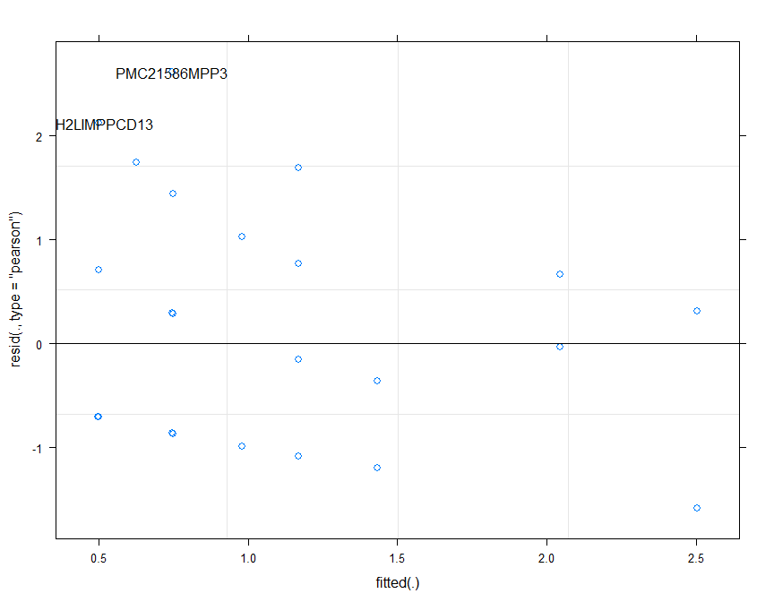

```r
plot(ageline_freq_model, id = 0.05, idLabels = healthy_freq$sample)
```

This code snippet will convert the residuals to Z scores and outputs the two-sided P value that is associated with that particular P value to check for significant outliers.

```r
healthy_freq$resids <- resid(healthy_freq_model, type = "pearson") %>%
  abs() %>%
  multiply_by(-1) %>%
  pnorm() %>%
  multiply_by(2) %>%
  p.adjust(method = "fdr")
```

Save the summary in a variable and add the fitted values to the dataframe for plotting.

```r
sum_ageline_freq <- summary(ageline_freq_model)

healthy_freq$fit <- predict(ageline_freq_model, re.form=NA)

pval <- formatC(sum_ageline_freq$coefficients[2,4],
               digits = 6,
               format = 'f')
```

Finally, plot the model:

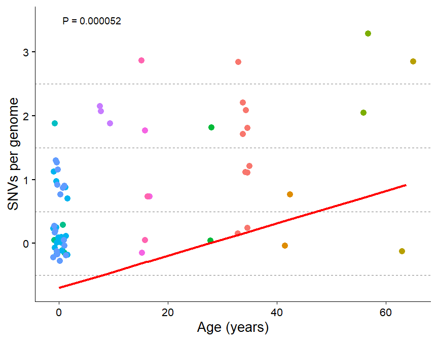

```r
# Model healthy variant ageline plot

plotname <- paste(plotdir,'model','MT_model_healthy_ageline', sep ='/')

plot_ageline <- ggplot(healthy_freq,
                    aes(x = age, y = freq )) +
  geom_jitter(aes(col = patient),
              size = 4,
              width = 1.5,
              height = 0.3) +
  geom_hline(yintercept = c(-0.5,0.5,1.5,2.5),
             linetype = 2,
             alpha = 0.5) +
  geom_line(aes(y = fit),
            size = 1.5,
            color = 'red') +
  ylab("SNVs per genome") +
  xlab("Age (years)") +
  guides(color = F) +
  annotate(geom='text',
           x = 6,
           y = 3.5,
           label = paste('P',pval, sep = ' = '),
           size = 5) +
  theme_BM()

plot_ageline
```

```r
ggsave(paste(plotname,
             'pdf',
             sep = '.'),
       width = 11.69,
       height = 8.27,
       plot_ageline,
       device = 'pdf')
```

Here is a different GLMM model created. In addition to age (as it was significant in the previous model), we want to look whether the disease state has any effect on the number of somatic mutations:

```r
foetus_freq$state <- factor(foetus_freq$state, levels = c('healthy','trisomy'))

foetus_freq_model <- glmer(freq ~ state + age + (0 + age | patient),
                           data = foetus_freq,
                           family = poisson)
```

Plot the residuals, annotating any possible outliers:

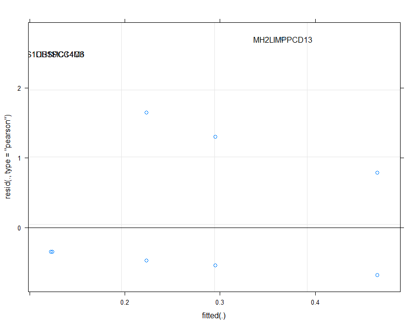

```r
plot(foetus_freq_model, id = 0.05, idLabels = foetus_freq$sample)
```

Find significant outliers and save model data in variables.

```r
foetus_freq$resids <- resid(foetus_freq_model, type = "pearson") %>%
  abs() %>%
  multiply_by(-1) %>%
  pnorm() %>%
  multiply_by(2) %>%
  p.adjust(method = "fdr")

sum_foetus_freq <- summary(foetus_freq_model)

foetus_freq$fit <- predict(foetus_freq_model, re.form=NA)

pval <- formatC(sum_foetus_freq$coefficients[2,4], digits = 4, format = 'f')
```

Finally, plot the model.

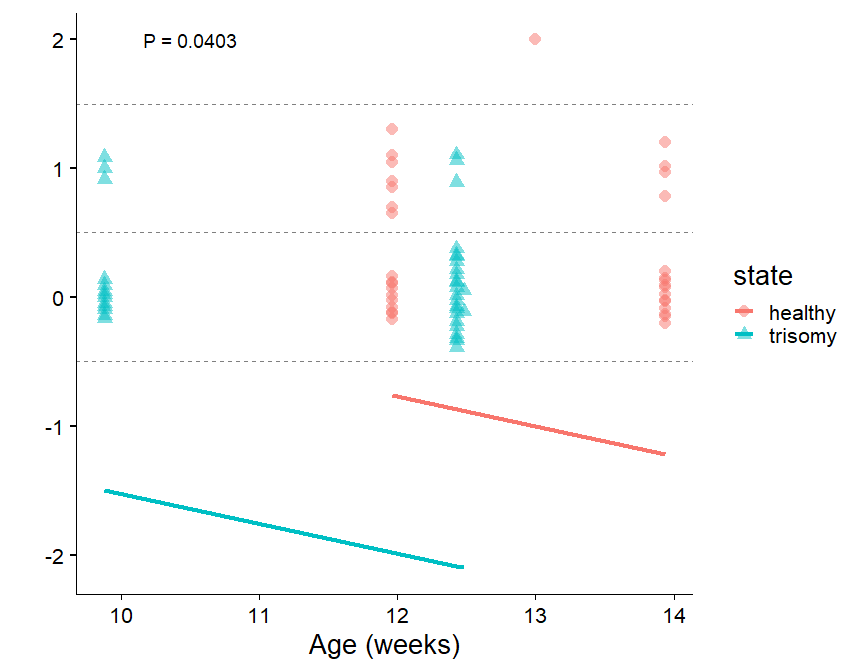

```r
plot_foetus_freq <- ggplot(foetus_freq,
                     aes(x = age * 52,
                         y = freq )) +
  geom_line(aes(y = fit, col = state),
            size = 1.5) +
  geom_quasirandom(aes(col = state, shape = state),
                   size = 4,
                   alpha = 0.5,
                   width = 0.4,
                   groupOnX = F) +
  geom_hline(yintercept = c(-0.5,0.5,1.5),
             linetype = 2,
             alpha = 0.5) +
  ylab(" ") +
  xlab("Age (weeks)") +
  annotate(geom='text',
           x= 10.5,
           y = 2,
           label = paste('P',pval, sep = ' = '),
           size = 5) +
  theme_BM() +
  guides(fill = F)

plot_foetus_freq
```

### LME Modelling

Because the copy number is a continuous variable, the model is created with regular linear-mixed effects modelling using the **NLME** R package. The function notation is slightly different, as you have to split the random component of your model. Here, the response variable, age a random effect and patient the grouping factor. A random slope for age will be modelled.

```r
ageline_cnv_model <- lme(cnv_mean ~ age,
          random = ~ 0 + age | patient,
          data = healthy_cnv)
```

Plot the residuals, where potential outliers are annotated.

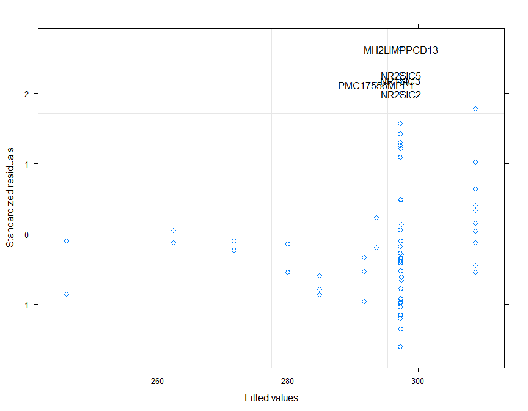

```r
plot(ageline_cnv_model, id = 0.05, idLabels = healthy_cnv$sample)
```

Add Z-score p values based on the residuals to the dataframe, and save some model data in variables.

```r
healthy_cnv$resids <- resid(ageline_cnv_model, type = "pearson") %>%
  abs() %>%
  multiply_by(-1) %>%
  pnorm() %>%
  multiply_by(2) %>%
  p.adjust(method = "fdr")

sum_ageline_cnv <- summary(ageline_cnv_model)

healthy_cnv$fit <- predict(ageline_cnv_model, level = 0)

pval <- formatC(sum_ageline_cnv$tTable[2,5],
                digits = 3,
                format = 'f')
```

Finally, plot the model:

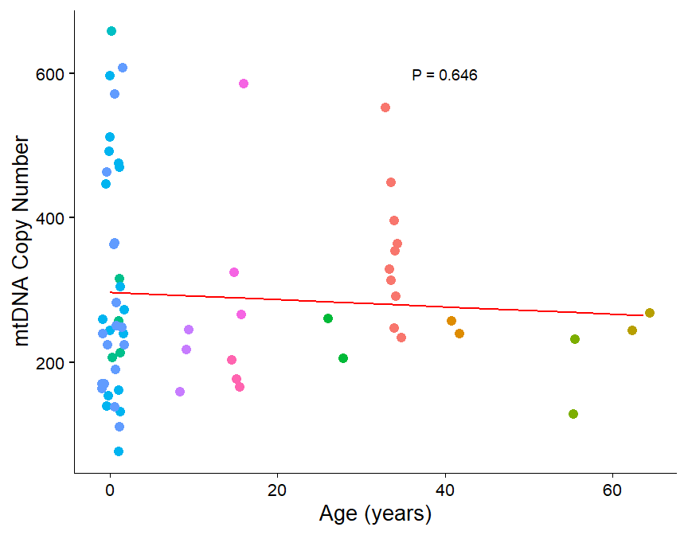

```r
# Model healthy cnv ageline plot
plot_healthy_cnv = ggplot(healthy_cnv,
                    aes(x = age,
                        y = cnv_mean )) +
  geom_jitter(aes(col = patient),
              size = 4,
              width = 1.5,
              height = 0.3) +
  geom_line(aes(y = fit),
            color = 'red',
            size = 1) +
  annotate(geom='text',
           x = 40,
           y = 600,
           label = paste('P',pval, sep = ' = '),
           size = 5) +
  ylab("mtDNA Copy Number") +
  xlab("Age (years)") +
  theme_BM() +
  guides(color = F)
plot_healthy_cnv
```

If you have any further questions, reach out to me (j.t.vandinter-3@prinsesmaximacentrum.nl) or Freek Manders (f.m.Manders@prinsesmaximacentrum.nl.